# Metabolic Power Calculations

Brent Scott

### Question 1

#### Take a peak at Parvo data at 14.01 min:

```r
library(magrittr)
library(tidyverse)
library(DT)
library(cowplot)

parvo_data <- read_csv("parvo-data.csv",
                       show_col_types = F)

parvo_data$time_min <- as.numeric(parvo_data$time_min)

kg <- 68.27

data_14 <-
  parvo_data %>%
   filter(time_min >= 14.01) %>%
   slice(1) %>%
   mutate(across(where(is.numeric), ~round(., digits = 4)))

datatable(data_14, options = list(scrollX = TRUE))
```

|  | time_min | vo2_liter_min | vo2_per_kg | METS | vco2_liter_min | ve_liters_min | RER | RR | Vt | FEO2 | FECO2 | cho_percent | fat_percent | ree_kcal_min |
| --- | --- | --- | --- | --- | --- | --- | --- | --- | --- | --- | --- | --- | --- | --- |
| 1 | 14.0103 | 3.9456 | 57.7915 | 16.5118 | 3.2944 | 80.1784 | 0.835 | 43.6364 | 2.7014 | 16.1891 | 4.1492 | 45.7253 | 54.7209 | 19.0116 |

#### Using this data calculate W/kg using 5 different methods:

```r
question1 <- function(vo2_liter_min, vco2_liter_min, mets, kg){
  #convert volume/min to volume/sec
  vo2 <- vo2_liter_min/60
  vco2 <- vco2_liter_min/60

  #4 equations, plug & chug
  #equations give kJ/s so convert to joules and make relative to body mass
  peronnet <- ((( 16.89 * vo2 ) + ( 4.84 * vco2 )) * 1000 ) / kg

  brockway <- ((( 16.58 * vo2 ) + ( 4.51 * vco2 )) * 1000 ) / kg

  original_weir <- ((( 16.50 * vo2 ) + ( 4.62 * vco2 )) * 1000 ) / kg

  corrected_weir <- ((( 16.62 * vo2 ) + (4.51 * vco2 )) * 1000 ) / kg

  #for part e, METs to Watts/kg
  o2_ml_kg_min <- mets*3.5
  ml_min <- o2_ml_kg_min * kg
  l_min <- ml_min / 1000
  kcal_min <- l_min * 5.05
  watts <- kcal_min/0.01433075379765
  watts_kg <- watts/kg

  df <-
    tibble(Question = letters[1:5],
         Equation = c("Peronnet", "Brockway", "OG Weir", "Corrected Weir", "METs"),
         Value = c(peronnet, brockway, original_weir, corrected_weir, watts_kg))

  return(df)
}

#plug in parvo data at 14.01 minutes and solve
answer1 <-
  question1(vo2_liter_min = data_14$vo2_liter_min,
            vco2_liter_min = data_14$vco2_liter_min,
            mets = data_14$METS,
            kg = kg) %>%
  mutate(Value = round(Value, 3))


datatable(answer1)
```

|  | Question | Equation | Value |
| --- | --- | --- | --- |
| 1 | a | Peronnet | 20.162 |
| 2 | b | Brockway | 19.598 |
| 3 | c | OG Weir | 19.609 |
| 4 | d | Corrected Weir | 19.636 |
| 5 | e | METs | 20.365 |

### Question 2

#### **2a & b)** Weighted average of VO2 and VCO2

```r
#calculate elapsed time between each epoch/row/obs/whatever
data_last_2_min <-
  parvo_data %>%
  mutate(time_elapsed_sec = (time_min - lag(time_min))*60) %>%
  filter(time_min >= 13.19 & time_min <= 15.17)

#find total elapsed time for period
total_time <- sum(data_last_2_min$time_elapsed_sec)

#Calculate weighted values and sum
answer2ab <-
  data_last_2_min %>%
  mutate(weight = time_elapsed_sec/total_time,
         vo2_weighted = vo2_liter_min * weight,
         vco2_weighted = vco2_liter_min * weight) %>%
  summarize("VO2 Weighted Avg" = sum(vo2_weighted),
            "VCO2 Weighted Avg" = sum(vco2_weighted),
            "VO2 Mean" = mean(vo2_liter_min),
            "VCO2 Mean" = mean(vco2_liter_min)) %>%
  mutate(across(where(is.numeric), ~round(., 4)))

answer2ab
```

| VO2 Weighted Avg | VCO2 Weighted Avg | VO2 Mean | VCO2 Mean |
| --- | --- | --- | --- |
| 4.0168 | 3.344 | 4.0178 | 3.345 |

#### **2c)** Metabolic Rate using P&M

```r
#convert to liters/sec, plug & chug. convert kJ to J
pm_2c <- ((( 16.89 * answer2ab$`VO2 Weighted Avg`/60 ) + ( 4.84 * answer2ab$`VCO2 Weighted Avg`/60 )) * 1000 ) / kg
```

#### The metabolic rate using the values from 2a & 2b is **20.514 W/kg**

#### **2d)** For every sample in last 2min calculate metabolic rate with P&M

```r
pm <- function(vo2, vco2, kg, ...){
  ((( 16.89 * vo2/60 ) + ( 4.84 * vco2/60 )) * 1000 ) / kg
}

data_2d <-
  data_last_2_min %>%
  mutate(metabolic_rate = pm(vo2_liter_min, vco2_liter_min, kg))


data_2d %>%
  mutate(across(where(is.numeric), ~round(., 3))) %>%
  select(time_min, vo2_liter_min, vco2_liter_min, metabolic_rate)
```

| time_min | vo2_liter_min | vco2_liter_min | metabolic_rate |
| --- | --- | --- | --- |
| 13.192 | 3.910 | 3.287 | 20.006 |
| 13.258 | 3.875 | 3.263 | 19.834 |
| 13.352 | 3.918 | 3.261 | 20.007 |
| 13.441 | 4.009 | 3.329 | 20.465 |
| 13.503 | 3.885 | 3.249 | 19.860 |
| 13.594 | 4.065 | 3.376 | 20.752 |
| 13.682 | 4.044 | 3.364 | 20.648 |
| 13.753 | 4.090 | 3.395 | 20.876 |
| 13.834 | 4.114 | 3.445 | 21.034 |
| 13.919 | 4.038 | 3.369 | 20.629 |

[output cut: 14 more lines]

#### **2e)** Calculate weighted average as of 2d

```r
weighted_data <-
  data_2d %>%
  mutate(weight = time_elapsed_sec/total_time,
         met_rate_weight = metabolic_rate * weight)

weight_avg_2d <-
  weighted_data %>%
  summarize("Weighted Average of 2d (L/min)" = sum(met_rate_weight)) %>%
  pull()

weight_avg_2d
```

```
## [1] 20.51398
```

### Question 3

**3a & b)** The metabolic cart measures air flow from the participants mouth at the analyzer where the house connects to the cart. The air must travel down the hose before flow is measured. To learn how the metabolic cart works Chris and I read the manual. The cart has a paramagnetic oxygen analyzer and a infrared carbon dioxide analyzer. Additionally the cart uses a pneumotach flow measurement device to measure air flow. Air flow is then converted to a pressure signal. The pressure signal is converted to an electrical voltage signal to be send to a comupter/recording device. The flow-pressure sensor works on the basis of Poiseuille’s Law:

$$\Delta p = 8\pi \mu L Q / A^2$$
where L is the length of the pipe, Q is flow rate, and A is the cross section of the pipe.

**3c)** Dimension of mixing chamber per manual of 5“x5”12.5" (4lbs). The volume is 4 liters.

```r
air_per_sec <- sum(data_last_2_min$Vt)/120
time_to_fill_chamber <- round(4/air_per_sec, 2)
```

It takes approximately 7.58 seconds to fill the chamber.

**3d)** I think I like the 2d-e method better where metabolic rate was calculated for each time point and then averaged because then you get a weighted mean/sd vs a single value. This would then allow you to run statistical tests if you wanted to do so.

### Question 4

#### Plot of oxygen uptake over time for trial 2 (9.93-15.17). Note: time has been normalized back to 0.

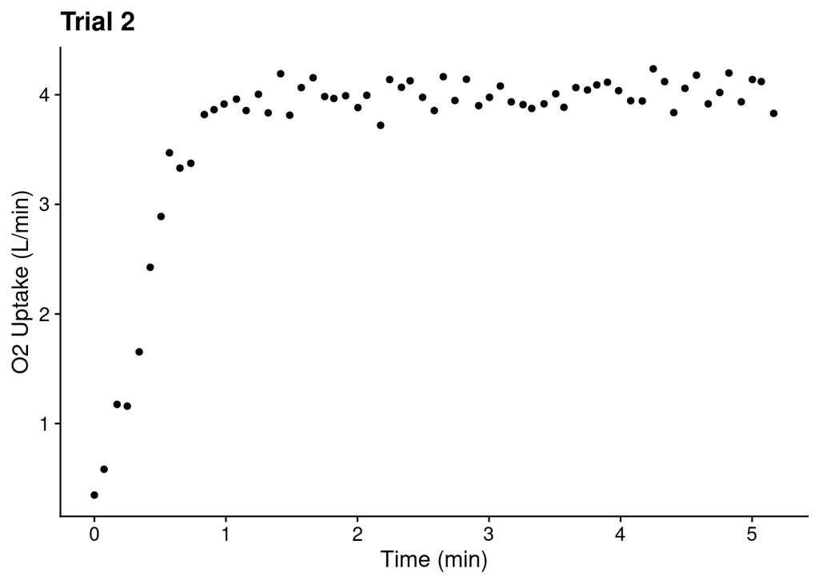

```r
data_q4 <-
  parvo_data %>%
  filter(time_min >= 9.93 & time_min <= 15.17)

time_to_substract <- head(data_q4, 1)$time_min

data_q4 %<>% mutate(time_min = time_min - time_to_substract)

p <-
  ggplot(data_q4)+
    geom_point(aes(time_min, vo2_liter_min))+
    ylab("O2 Uptake (L/min)")+
    xlab("Time (min)")+
    ggtitle("Trial 2")+
    theme_cowplot()
p
```

#### Try to take a guess at parameters A and tau.

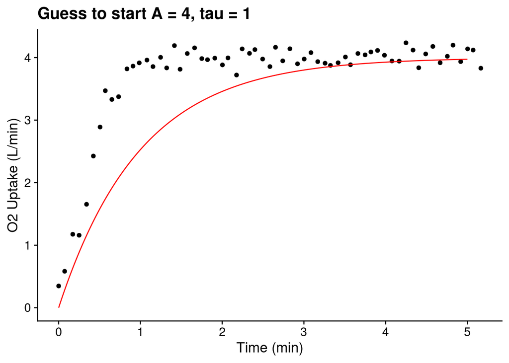

```r
#4, 1
guess <-  tibble(x = seq(0, 5, by = 0.01),
                 y = 4*(1-exp(-(x/1))))
p + geom_line(data = guess, aes(x, y), color = "red")+
  ggtitle("Guess to start A = 4, tau = 1")
```

#### Calculate residual sum of squares for guess

```r
data_q4_guess <-
  data_q4 %>%
  mutate(guess_y = 4*(1-exp(-(time_min/1))),
         residual = (vo2_liter_min - guess_y)^2)

sum(data_q4_guess$residual)
```

```
## [1] 28.9999
```

#### Fit

```r
mod <- nls(vo2_liter_min ~ A*(1-exp(time_min/-tau)),
           data = data_q4,
           start = list(A = 4, tau = 1))

summary(mod)
```

```
##
## Formula: vo2_liter_min ~ A * (1 - exp(time_min/-tau))
##
## Parameters:
##     Estimate Std. Error t value Pr(>|t|)
## A    4.04619    0.02917  138.71   <2e-16 ***
## tau  0.41884    0.01986   21.09   <2e-16 ***
## ---
## Signif. codes:  0 '***' 0.001 '**' 0.01 '*' 0.05 '.' 0.1 ' ' 1
##
## Residual standard error: 0.1925 on 61 degrees of freedom
##
## Number of iterations to convergence: 9
## Achieved convergence tolerance: 1.823e-06
```

```r
paste0("The model residual sum of squares is: ", round(sum(resid(mod)^2), 3))
```

```
## [1] "The model residual sum of squares is: 2.261"
```

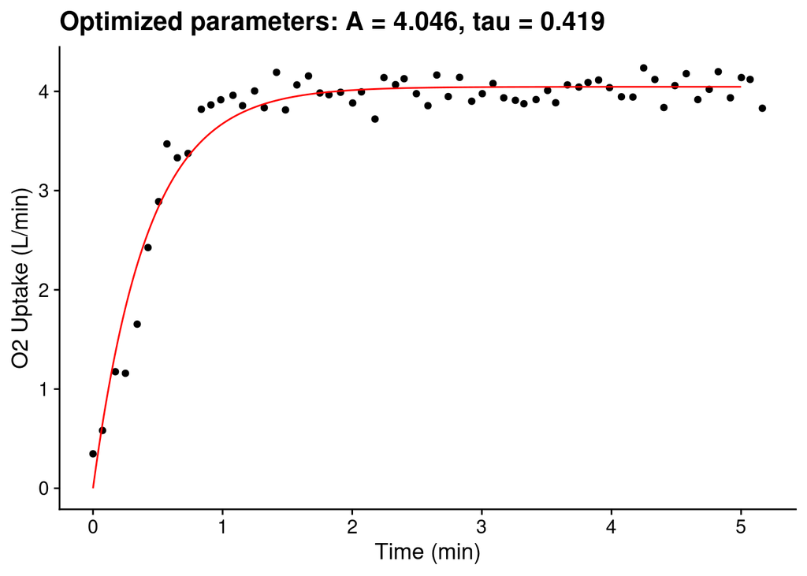

```r
mod_line <- data.frame(y = predict(mod, newdata = data.frame(time_min = seq(0, 5, by = 1/100)))) %>%
  mutate(x = seq(0, 5, by = 1/100))

p+geom_line(data = mod_line, aes(x, y), color = 'red')+
  ggtitle(paste0("Optimized parameters: A = ", round(coef(mod)[[1]], 3), ", tau = ", round(coef(mod)[[2]], 3)))
```